# Part one

**• DOMAIN:** Healthcare

**• CONTEXT:** Medical research university X is undergoing a deep research on patients with certain conditions. University has an internal AI team. Due to confidentiality the patient’s details and the conditions are masked by the client by providing different datasets to the AI team for developing a AIML model which can predict the condition of the patient depending on the received test results.

**• DATA DESCRIPTION:** The data consists of biomechanics features of the patients according to their current conditions. Each patient is represented in the data set by six biomechanics attributes derived from the shape and orientation of the condition to their body part.

1. P_incidence
2. P_tilt
3. L_angle
4. S_slope
5. P_radius
6. S_degree
7. Class

```python
# importing all the necessary libraries

import numpy as nm
import pandas as pd
import matplotlib.pyplot as plt
%matplotlib inline
import seaborn as sns

from scipy.stats import zscore

from sklearn.model_selection import train_test_split
from sklearn.neighbors import KNeighborsClassifier
import imblearn
```

1. Import and warehouse data:  
   • Import all the given datasets and explore shape and size of each.  
   • Merge all datasets onto one and explore final shape and size.

```python
# importing all the datasets
normalData = pd.read_csv('Part1 - Normal.csv')
type_HData = pd.read_csv('Part1 - Type_H.csv')
type_SData = pd.read_csv('Part1 - Type_S.csv')
```

```python
#Printing shape and size of all the datasets

print("Shape and size of Normal dataset is {}".format(normalData.shape))
print("Shape and size of Type_H dataset is {}".format(type_HData.shape))
print("Shape and size of Type_S dataset is {}".format(type_SData.shape))
```

```
Shape and size of Normal dataset is (100, 7)
Shape and size of Type_H dataset is (60, 7)
Shape and size of Type_S dataset is (150, 7)
```

```python
# getting an insight of columns and the data contained within the dataset

print(normalData.head())
normalData.groupby(['Class']).count()
```

```
   P_incidence     P_tilt    L_angle    S_slope    P_radius  S_Degree   Class
0    38.505273  16.964297  35.112814  21.540976  127.632875  7.986683  Normal
1    54.920858  18.968430  51.601455  35.952428  125.846646  2.001642  Normal
2    44.362490   8.945435  46.902096  35.417055  129.220682  4.994195  Normal
3    48.318931  17.452121  48.000000  30.866809  128.980308 -0.910941  Normal
4    45.701789  10.659859  42.577846  35.041929  130.178314 -3.388910  Normal
```

| Class | P_incidence | P_tilt | L_angle | S_slope | P_radius | S_Degree |
| --- | --- | --- | --- | --- | --- | --- |
| Normal | 73 | 73 | 73 | 73 | 73 | 73 |
| Nrmal | 27 | 27 | 27 | 27 | 27 | 27 |

```python
print(type_HData.head())
type_HData.groupby(['Class']).count()
```

```
   P_incidence     P_tilt    L_angle    S_slope    P_radius   S_Degree   Class
0    63.027817  22.552586  39.609117  40.475232   98.672917  -0.254400  Type_H
1    39.056951  10.060991  25.015378  28.995960  114.405425   4.564259  Type_H
2    68.832021  22.218482  50.092194  46.613539  105.985135  -3.530317  Type_H
3    69.297008  24.652878  44.311238  44.644130  101.868495  11.211523  Type_H
4    49.712859   9.652075  28.317406  40.060784  108.168725   7.918501  Type_H
```

| Class | P_incidence | P_tilt | L_angle | S_slope | P_radius | S_Degree |
| --- | --- | --- | --- | --- | --- | --- |
| Type_H | 37 | 37 | 37 | 37 | 37 | 37 |
| type_h | 23 | 23 | 23 | 23 | 23 | 23 |

```python
print(type_SData.head())
type_SData.groupby(['Class']).count()
```

```
   P_incidence     P_tilt    L_angle    S_slope    P_radius   S_Degree   Class
0    74.377678  32.053104  78.772013  42.324573  143.560690  56.125906  Type_S
1    89.680567  32.704435  83.130732  56.976132  129.955476  92.027277  Type_S
2    44.529051   9.433234  52.000000  35.095817  134.711772  29.106575  Type_S
3    77.690577  21.380645  64.429442  56.309932  114.818751  26.931841  Type_S
4    76.147212  21.936186  82.961502  54.211027  123.932010  10.431972  Type_S
```

| Class | P_incidence | P_tilt | L_angle | S_slope | P_radius | S_Degree |
| --- | --- | --- | --- | --- | --- | --- |
| Type_S | 133 | 133 | 133 | 133 | 133 | 133 |
| tp_s | 17 | 17 | 17 | 17 | 17 | 17 |

When we did group by on Class column, we noticed that some of the vaues are misspelled or there is some case difference.

Lets consider Normal, Type_H and Type_S as the valid values and replace other corresponding values with the same.

```python
normalData['Class'] = normalData['Class'].replace({'Nrmal' : 'Normal'})
normalData.groupby(['Class']).count()
```

| Class | P_incidence | P_tilt | L_angle | S_slope | P_radius | S_Degree |
| --- | --- | --- | --- | --- | --- | --- |
| Normal | 100 | 100 | 100 | 100 | 100 | 100 |

```python
type_HData['Class'] = type_HData['Class'].replace({'type_h' : 'Type_H'})
type_HData.groupby(['Class']).count()
```

| Class | P_incidence | P_tilt | L_angle | S_slope | P_radius | S_Degree |
| --- | --- | --- | --- | --- | --- | --- |
| Type_H | 60 | 60 | 60 | 60 | 60 | 60 |

```python
type_SData['Class'] = type_SData['Class'].replace({'tp_s' : 'Type_S'})
type_SData.groupby(['Class']).count()
```

| Class | P_incidence | P_tilt | L_angle | S_slope | P_radius | S_Degree |
| --- | --- | --- | --- | --- | --- | --- |
| Type_S | 150 | 150 | 150 | 150 | 150 | 150 |

```python
# merging all datasets into one
medicalXData = pd.concat([normalData, type_HData, type_SData])

medicalXData.shape
```

```
(310, 7)
```

```python
medicalXData
```

|  | P_incidence | P_tilt | L_angle | S_slope | P_radius | S_Degree | Class |
| --- | --- | --- | --- | --- | --- | --- | --- |
| 0 | 38.505273 | 16.964297 | 35.112814 | 21.540976 | 127.632875 | 7.986683 | Normal |
| 1 | 54.920858 | 18.968430 | 51.601455 | 35.952428 | 125.846646 | 2.001642 | Normal |
| 2 | 44.362490 | 8.945435 | 46.902096 | 35.417055 | 129.220682 | 4.994195 | Normal |
| 3 | 48.318931 | 17.452121 | 48.000000 | 30.866809 | 128.980308 | -0.910941 | Normal |
| 4 | 45.701789 | 10.659859 | 42.577846 | 35.041929 | 130.178314 | -3.388910 | Normal |
| ... | ... | ... | ... | ... | ... | ... | ... |
| 145 | 80.111572 | 33.942432 | 85.101608 | 46.169139 | 125.593624 | 100.292107 | Type_S |
| 146 | 95.480229 | 46.550053 | 59.000000 | 48.930176 | 96.683903 | 77.283072 | Type_S |
| 147 | 74.094731 | 18.823727 | 76.032156 | 55.271004 | 128.405731 | 73.388216 | Type_S |
| 148 | 87.679087 | 20.365613 | 93.822416 | 67.313473 | 120.944829 | 76.730629 | Type_S |
| 149 | 48.259920 | 16.417462 | 36.329137 | 31.842457 | 94.882336 | 28.343799 | Type_S |

310 rows × 7 columns

**Here, we can see that the final number of rows are 310 which is a sum of all the 3 datasets row numbers.**

**2. Data cleansing:**  
• Explore and if required correct the datatypes of each attribute.  
• Explore for null values in the attributes and if required drop or impute values.

```python
# Checking the datatypes of each column

medicalXData.dtypes
```

```
P_incidence    float64
P_tilt         float64
L_angle        float64
S_slope        float64
P_radius       float64
S_Degree       float64
Class           object
dtype: object
```

Datatypes for all the columns looks fine, we dont need to change it.

```python
medicalXData.info()
```

```
<class 'pandas.core.frame.DataFrame'>
Int64Index: 310 entries, 0 to 149
Data columns (total 7 columns):
 #   Column       Non-Null Count  Dtype
---  ------       --------------  -----
 0   P_incidence  310 non-null    float64
 1   P_tilt       310 non-null    float64
 2   L_angle      310 non-null    float64
 3   S_slope      310 non-null    float64
 4   P_radius     310 non-null    float64
 5   S_Degree     310 non-null    float64
 6   Class        310 non-null    object
dtypes: float64(6), object(1)
memory usage: 19.4+ KB
```

```python
medicalXData.isna().sum()
```

```
P_incidence    0
P_tilt         0
L_angle        0
S_slope        0
P_radius       0
S_Degree       0
Class          0
dtype: int64
```

```python
medicalXData.isnull().values.any()
```

```
False
```

**As we can see there is no null values and also their might not be any unpredicted string values as datatypes for all the columns is of type float apart from Class which is expected to be object.**

**3. Data analysis & visualisation:**  
• Perform detailed statistical analysis on the data.  
• Perform a detailed univariate, bivariate and multivariate analysis with appropriate detailed comments after each analysis.

```python
medicalXData.describe()
```

|  | P_incidence | P_tilt | L_angle | S_slope | P_radius | S_Degree |
| --- | --- | --- | --- | --- | --- | --- |
| count | 310.000000 | 310.000000 | 310.000000 | 310.000000 | 310.000000 | 310.000000 |
| mean | 60.496653 | 17.542822 | 51.930930 | 42.953831 | 117.920655 | 26.296694 |
| std | 17.236520 | 10.008330 | 18.554064 | 13.423102 | 13.317377 | 37.559027 |
| min | 26.147921 | -6.554948 | 14.000000 | 13.366931 | 70.082575 | -11.058179 |
| 25% | 46.430294 | 10.667069 | 37.000000 | 33.347122 | 110.709196 | 1.603727 |
| 50% | 58.691038 | 16.357689 | 49.562398 | 42.404912 | 118.268178 | 11.767934 |
| 75% | 72.877696 | 22.120395 | 63.000000 | 52.695888 | 125.467674 | 41.287352 |
| max | 129.834041 | 49.431864 | 125.742385 | 121.429566 | 163.071041 | 418.543082 |

from the above statistical analysis based on the min values we can deduce that there is no zero value as well for any of the columns.

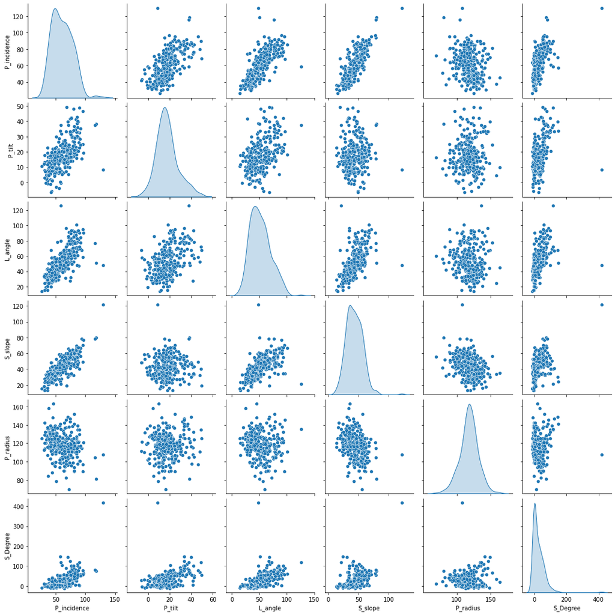

```python
sns.pairplot(medicalXData, diag_kind='kde');
```

```python
medicalXData.corr()
```

|  | P_incidence | P_tilt | L_angle | S_slope | P_radius | S_Degree |
| --- | --- | --- | --- | --- | --- | --- |
| P_incidence | 1.000000 | 0.629199 | 0.717282 | 0.814960 | -0.247467 | 0.638743 |
| P_tilt | 0.629199 | 1.000000 | 0.432764 | 0.062345 | 0.032668 | 0.397862 |
| L_angle | 0.717282 | 0.432764 | 1.000000 | 0.598387 | -0.080344 | 0.533667 |
| S_slope | 0.814960 | 0.062345 | 0.598387 | 1.000000 | -0.342128 | 0.523557 |
| P_radius | -0.247467 | 0.032668 | -0.080344 | -0.342128 | 1.000000 | -0.026065 |
| S_Degree | 0.638743 | 0.397862 | 0.533667 | 0.523557 | -0.026065 | 1.000000 |

From the above pair plot and correlation data, we can see that we have mixed data, some of the columns are somewhat correlated to each other like S_slope and P_incidence, L_angle and P_incidence.

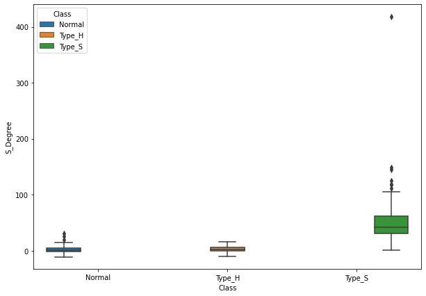

```python
plt.figure(figsize=(10,7))
sns.boxplot(data=medicalXData, x = 'Class', y = 'S_Degree', hue='Class');
```

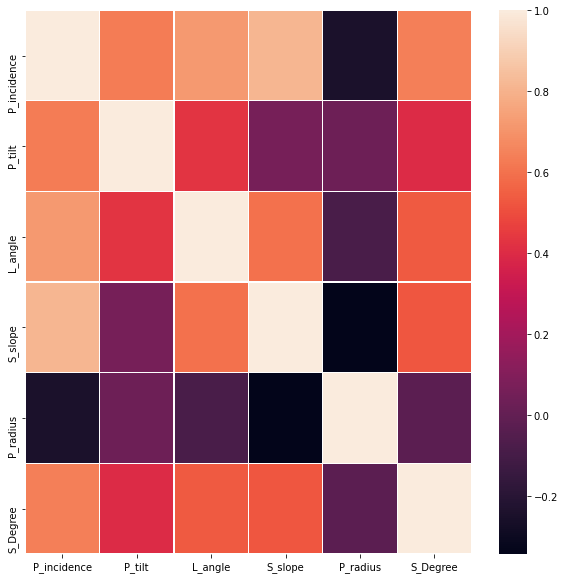

```python
columns = medicalXData.iloc[:,0:6]
plt.subplots(figsize=(10,10))
sns.heatmap(columns.corr(), linewidths=0.2)
```

I think, there will be not much strong point in creating any other bivariate plots, as the dependant variable Class is combinely dependant on all the columns. So, separatey plotting any one column for a Class variable will not help much.

**4. Data pre-processing:**  
• Segregate predictors vs target attributes  
• Perform normalisation or scaling if required.  
• Check for target balancing. Add your comments.  
• Perform train-test split.

```python
# Segregating predictors and target attributes

X = medicalXData.drop(labels='Class', axis=1)
y = medicalXData['Class']
```

```python
# let's perfom scacling by applying zscore. So, that all the values are of one scale

XScaled = X.apply(zscore)

XScaled
```

|  | P_incidence | P_tilt | L_angle | S_slope | P_radius | S_Degree |
| --- | --- | --- | --- | --- | --- | --- |
| 0 | -1.277922 | -0.057898 | -0.907904 | -1.597803 | 0.730468 | -0.488288 |
| 1 | -0.324010 | 0.142672 | -0.017786 | -0.522437 | 0.596124 | -0.647896 |
| 2 | -0.937559 | -0.860412 | -0.271475 | -0.562386 | 0.849889 | -0.568091 |
| 3 | -0.707649 | -0.009077 | -0.212206 | -0.901920 | 0.831811 | -0.725568 |
| 4 | -0.859732 | -0.688835 | -0.504914 | -0.590377 | 0.921914 | -0.791650 |
| ... | ... | ... | ... | ... | ... | ... |
| 145 | 1.139826 | 1.641245 | 1.790676 | 0.239923 | 0.577094 | 1.973295 |
| 146 | 2.032901 | 2.902995 | 0.381614 | 0.445948 | -1.597243 | 1.359695 |
| 147 | 0.790186 | 0.128191 | 1.301073 | 0.919094 | 0.788596 | 1.255828 |
| 148 | 1.579575 | 0.282500 | 2.261457 | 1.817689 | 0.227452 | 1.344962 |
| 149 | -0.711078 | -0.112624 | -0.842242 | -0.829118 | -1.732741 | 0.054592 |

310 rows × 6 columns

```python
XScaled.describe()
```

|  | P_incidence | P_tilt | L_angle | S_slope | P_radius | S_Degree |
| --- | --- | --- | --- | --- | --- | --- |
| count | 3.100000e+02 | 3.100000e+02 | 3.100000e+02 | 3.100000e+02 | 3.100000e+02 | 3.100000e+02 |
| mean | 1.042177e-16 | 2.096889e-16 | 1.980495e-16 | 2.829278e-17 | -5.071212e-16 | -1.277204e-16 |
| std | 1.001617e+00 | 1.001617e+00 | 1.001617e+00 | 1.001617e+00 | 1.001617e+00 | 1.001617e+00 |
| min | -1.996010e+00 | -2.411664e+00 | -2.047652e+00 | -2.207741e+00 | -3.597963e+00 | -9.961725e-01 |
| 25% | -8.173982e-01 | -6.881138e-01 | -8.060267e-01 | -7.168418e-01 | -5.423830e-01 | -6.585073e-01 |
| 50% | -1.049246e-01 | -1.186061e-01 | -1.278621e-01 | -4.095971e-02 | 2.613767e-02 | -3.874502e-01 |
| 75% | 7.194643e-01 | 4.581158e-01 | 5.975493e-01 | 7.269414e-01 | 5.676209e-01 | 3.997679e-01 |
| max | 4.029206e+00 | 3.191402e+00 | 3.984615e+00 | 5.855771e+00 | 3.395818e+00 | 1.046035e+01 |

```python
# Lets split the data into training and testing
X_train, X_test, y_train, y_test = train_test_split(XScaled, y, test_size=0.30, random_state=1, stratify=y)
```

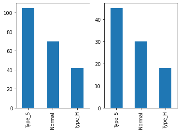

```python
plt.subplot(1,2,1)
y_train.value_counts().plot(kind = 'bar')

plt.subplot(1,2,2)
y_test.value_counts().plot(kind = 'bar')
plt.show()
```

```python
from imblearn.over_sampling import SMOTE
smote = SMOTE()
X_train, y_train = smote.fit_resample(X_train, y_train)
X_test, y_test = smote.fit_resample(X_test,y_test)
```

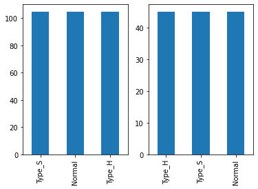

```python
plt.subplot(1,2,1)
y_train.value_counts().plot(kind = 'bar')

plt.subplot(1,2,2)
y_test.value_counts().plot(kind = 'bar')
plt.show()
```

**• Check for target balancing. Add your comments.**

- I have replaced the target column by choosing Normal, Type_H and Type_S to be the class types. any other equivalent values for these coulmns like Nrml, tp_s, type_h are replaced in previous steps itself.
- Final data set "medicalXData" contains data from all the dataset and target variable has been balanced now using SMOTE technique.

```python
print("Percentage of X_train data is {}".format(len(X_train)/len(XScaled)*100))
print("Percentage of X_test data is {}".format(len(X_test)/len(XScaled)*100))

print("Percentage of y_train data is {}".format(len(y_train)/len(XScaled)*100))
print("Percentage of y_test data is {}".format(len(y_test)/len(XScaled)*100))
```

```
Percentage of X_train data is 101.61290322580645
Percentage of X_test data is 43.54838709677419
Percentage of y_train data is 101.61290322580645
Percentage of y_test data is 43.54838709677419
```

**5. Model training, testing and tuning:**  
• Design and train a KNN classifier.  
• Display the classification accuracies for train and test data.  
• Display and explain the classification report in detail.  
• Automate the task of finding best values of K for KNN.  
• Apply all the possible tuning techniques to train the best model for the given data. Select the final best trained model with your comments for selecting this model.

## Building KNN Model

```python
KNN = KNeighborsClassifier(n_neighbors=7, algorithm='auto', weights='distance')
```

```python
KNN.fit(X_train, y_train)
```

```
KNeighborsClassifier(n_neighbors=7, weights='distance')
```

```python
KNN.score(X_train,y_train)
```

```
1.0
```

```python
y_predicted = KNN.predict(X_test)
KNN.score(X_test,y_test)
```

```
0.7407407407407407
```

```python
# importing metrics librabry for acuracy measures and confusion metrics

from sklearn import metrics
from sklearn.metrics import accuracy_score
from sklearn.metrics import recall_score
from sklearn.metrics import precision_score

print(accuracy_score(y_test, y_predicted))
print(precision_score(y_test, y_predicted, average='micro'))
print(recall_score(y_test,y_predicted, average='micro'))
```

```
0.7407407407407407
0.7407407407407407
0.7407407407407407
```

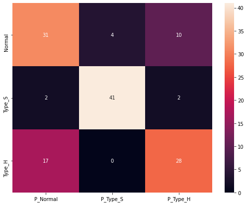

```python
cm = metrics.confusion_matrix(y_test, y_predicted, labels=['Normal', 'Type_S', 'Type_H'])

df_cm = pd.DataFrame(cm,
                    index = [i for i in ['Normal', 'Type_S', 'Type_H']],
                    columns= [i for i in ['P_Normal', 'P_Type_S', 'P_Type_H']])

plt.figure(figsize=(9,7))
sns.heatmap(df_cm, annot=True);
```

```python
# Automate the task of finding best values of K for KNN.

scores =[]
for k in range(1,50):
    NNH = KNeighborsClassifier(n_neighbors = k, weights = 'distance' )
    NNH.fit(X_train, y_train)
    scores.append(NNH.score(X_test, y_test))
```

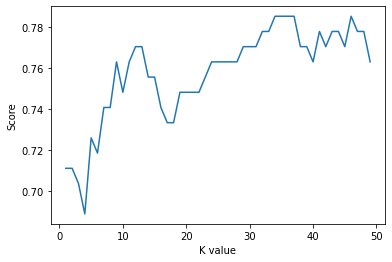

```python
plt.plot(range(1,50),scores)
plt.xlabel('K value')
plt.ylabel('Score')
```

## Build Naive Bayes Model

```python
from sklearn.naive_bayes import GaussianNB
```

```python
GNB = GaussianNB()

GNB.fit(X_train,y_train)
```

```
GaussianNB()
```

```python
y_predictedGNB = GNB.predict(X_test)
GNB.score(X_train,y_train)
```

```
0.8507936507936508
```

```python
GNB.score(X_test,y_test)
```

```
0.8
```

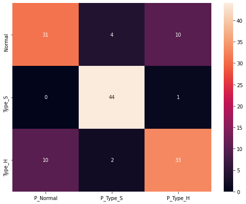

```python
cm = metrics.confusion_matrix(y_test, y_predictedGNB, labels=['Normal', 'Type_S', 'Type_H'])

df_cm = pd.DataFrame(cm,
                    index = [i for i in ['Normal', 'Type_S', 'Type_H']],
                    columns= [i for i in ['P_Normal', 'P_Type_S', 'P_Type_H']])

plt.figure(figsize=(9,7))
sns.heatmap(df_cm, annot=True);
```

## Building Naive-Bayes Bernoulli Model

```python
from sklearn.naive_bayes import BernoulliNB
```

```python
BNB = BernoulliNB(alpha=1)
BNB.fit(X_train,y_train)
```

```
BernoulliNB(alpha=1)
```

```python
y_predictedBNB = BNB.predict(X_test)
BNB.score(X_train,y_train)
```

```
0.8253968253968254
```

```python
BNB.score(X_test,y_test)
```

```
0.762962962962963
```

**6. Conclusion and improvisation:**

- This data looks quite good as there are no null values and no unexpected string values. Due to which we did not have to replace anything with mean values or drop any coumns.
- There can be seen some outliers for Type_S data, though it is the best fitting data.
- There are some outliers in Normal data as well.

# Part Two

• **DOMAIN:** Banking and finance  
• **CONTEXT:** A bank X is on a massive digital transformation for all its departments. Bank has a growing customer base whee majority of them are liability customers (depositors) vs borrowers (asset customers). The bank is interested in expanding the borrowers base rapidly to bring in more business via loan interests. A campaign that the bank ran in last quarter showed an average single digit conversion rate. Digital transformation being the core strength of the business strategy, marketing department wants to devise effective campaigns with better target marketing to increase the conversion ratio to double digit with same budget as per last campaign.  
• **DATA DESCRIPTION:** The data consists of the following attributes:

1. ID: Customer ID
2. Age Customer’s approximate age.
3. CustomerSince: Customer of the bank since. [unit is masked]
4. HighestSpend: Customer’s highest spend so far in one transaction. [unit is masked]
5. ZipCode: Customer’s zip code.
6. HiddenScore: A score associated to the customer which is masked by the bank as an IP.
7. MonthlyAverageSpend: Customer’s monthly average spend so far. [unit is masked]
8. Level: A level associated to the customer which is masked by the bank as an IP.
9. Mortgage: Customer’s mortgage. [unit is masked]
10. Security: Customer’s security asset with the bank. [unit is masked]
11. FixedDepositAccount: Customer’s fixed deposit account with the bank. [unit is masked]
12. InternetBanking: if the customer uses internet banking.
13. CreditCard: if the customer uses bank’s credit card.
14. LoanOnCard: if the customer has a loan on credit card.

### 1. Import and warehouse data:

• Import all the given datasets and explore shape and size of each.  
• Merge all datasets onto one and explore final shape and size

```python
# importing given datasets individually
p2_data1 = pd.read_csv("Part2 - Data1.csv")
p2_data2 = pd.read_csv("Part2 -Data2.csv")
```

```python
#Printing shape and size of all the datasets

print("Shape and size of data1 dataset is {}".format(p2_data1.shape))
print("Shape and size of data2 dataset is {}".format(p2_data2.shape))
```

```
Shape and size of data1 dataset is (5000, 8)
Shape and size of data2 dataset is (5000, 7)
```

Individually data1 containd 5000 rows and 8 columns and data2 contains 5000 rows and 7 columns

```python
# getting an insight of columns and the data contained within the dataset

p2_data1.head()
```

|  | ID | Age | CustomerSince | HighestSpend | ZipCode | HiddenScore | MonthlyAverageSpend | Level |
| --- | --- | --- | --- | --- | --- | --- | --- | --- |
| 0 | 1 | 25 | 1 | 49 | 91107 | 4 | 1.6 | 1 |
| 1 | 2 | 45 | 19 | 34 | 90089 | 3 | 1.5 | 1 |
| 2 | 3 | 39 | 15 | 11 | 94720 | 1 | 1.0 | 1 |
| 3 | 4 | 35 | 9 | 100 | 94112 | 1 | 2.7 | 2 |
| 4 | 5 | 35 | 8 | 45 | 91330 | 4 | 1.0 | 2 |

```python
p2_data2.head()
```

|  | ID | Mortgage | Security | FixedDepositAccount | InternetBanking | CreditCard | LoanOnCard |
| --- | --- | --- | --- | --- | --- | --- | --- |
| 0 | 1 | 0 | 1 | 0 | 0 | 0 | NaN |
| 1 | 2 | 0 | 1 | 0 | 0 | 0 | NaN |
| 2 | 3 | 0 | 0 | 0 | 0 | 0 | NaN |
| 3 | 4 | 0 | 0 | 0 | 0 | 0 | NaN |
| 4 | 5 | 0 | 0 | 0 | 0 | 1 | NaN |

```python
p2_data2['LoanOnCard'].value_counts(normalize=True)
```

```
0.0    0.903614
1.0    0.096386
Name: LoanOnCard, dtype: float64
```

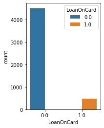

```python
plt.subplot(1,2,1)
sns.countplot(data = p2_data2, x = 'LoanOnCard', hue='LoanOnCard')
```

```python
p2_data2.groupby(['LoanOnCard']).count()
```

| LoanOnCard | ID | Mortgage | Security | FixedDepositAccount | InternetBanking | CreditCard |
| --- | --- | --- | --- | --- | --- | --- |
| 0.0 | 4500 | 4500 | 4500 | 4500 | 4500 | 4500 |
| 1.0 | 480 | 480 | 480 | 480 | 480 | 480 |

#### We can see that the data is highly imbalanced. Which we wil deal with in later questions

##### • Merge all datasets onto one and explore final shape and size

```python
#bankData = pd.concat([p2_data1, p2_data2])

bankData = p2_data1.merge(p2_data2)

print("Final shape of the dataset after merging is: {}".format(bankData.shape))
```

```
Final shape of the dataset after merging is: (5000, 14)
```

The dataset contains 5000 rows and 14 columns

```python
bankData
```

|  | ID | Age | CustomerSince | HighestSpend | ZipCode | HiddenScore | MonthlyAverageSpend | Level | Mortgage | Security | FixedDepositAccount | InternetBanking | CreditCard | LoanOnCard |
| --- | --- | --- | --- | --- | --- | --- | --- | --- | --- | --- | --- | --- | --- | --- |
| 0 | 1 | 25 | 1 | 49 | 91107 | 4 | 1.6 | 1 | 0 | 1 | 0 | 0 | 0 | NaN |
| 1 | 2 | 45 | 19 | 34 | 90089 | 3 | 1.5 | 1 | 0 | 1 | 0 | 0 | 0 | NaN |
| 2 | 3 | 39 | 15 | 11 | 94720 | 1 | 1.0 | 1 | 0 | 0 | 0 | 0 | 0 | NaN |
| 3 | 4 | 35 | 9 | 100 | 94112 | 1 | 2.7 | 2 | 0 | 0 | 0 | 0 | 0 | NaN |
| 4 | 5 | 35 | 8 | 45 | 91330 | 4 | 1.0 | 2 | 0 | 0 | 0 | 0 | 1 | NaN |
| ... | ... | ... | ... | ... | ... | ... | ... | ... | ... | ... | ... | ... | ... | ... |
| 4995 | 4996 | 29 | 3 | 40 | 92697 | 1 | 1.9 | 3 | 0 | 0 | 0 | 1 | 0 | 0.0 |
| 4996 | 4997 | 30 | 4 | 15 | 92037 | 4 | 0.4 | 1 | 85 | 0 | 0 | 1 | 0 | 0.0 |
| 4997 | 4998 | 63 | 39 | 24 | 93023 | 2 | 0.3 | 3 | 0 | 0 | 0 | 0 | 0 | 0.0 |
| 4998 | 4999 | 65 | 40 | 49 | 90034 | 3 | 0.5 | 2 | 0 | 0 | 0 | 1 | 0 | 0.0 |
| 4999 | 5000 | 28 | 4 | 83 | 92612 | 3 | 0.8 | 1 | 0 | 0 | 0 | 1 | 1 | 0.0 |

5000 rows × 14 columns

### 2. Data cleansing:

• Explore and if required correct the datatypes of each attribute  
• Explore for null values in the attributes and if required drop or impute values.

```python
bankData.dtypes
```

```
ID                       int64
Age                      int64
CustomerSince            int64
HighestSpend             int64
ZipCode                  int64
HiddenScore              int64
MonthlyAverageSpend    float64
Level                    int64
Mortgage                 int64
Security                 int64
FixedDepositAccount      int64
InternetBanking          int64
CreditCard               int64
LoanOnCard             float64
dtype: object
```

There is no need to change the data type as categorical columns are already containing values in 0 and 1 format

```python
bankData.isnull().values.any()
```

```
True
```

```python
#bankData = bankData.dropna(axis=0)

bankData.isna().sum()
```

```
ID                      0
Age                     0
CustomerSince           0
HighestSpend            0
ZipCode                 0
HiddenScore             0
MonthlyAverageSpend     0
Level                   0
Mortgage                0
Security                0
FixedDepositAccount     0
InternetBanking         0
CreditCard              0
LoanOnCard             20
dtype: int64
```

```python
bankData = bankData.dropna(axis=0)
```

#### As there were only 20 rows with missing data, we dropped the data containing null values. Dropping the ID column as well, as it is of no use.

```python
bankData = bankData.drop('ID', axis =1 )
```

```python
bankData
```

|  | Age | CustomerSince | HighestSpend | ZipCode | HiddenScore | MonthlyAverageSpend | Level | Mortgage | Security | FixedDepositAccount | InternetBanking | CreditCard | LoanOnCard |
| --- | --- | --- | --- | --- | --- | --- | --- | --- | --- | --- | --- | --- | --- |
| 9 | 34 | 9 | 180 | 93023 | 1 | 8.9 | 3 | 0 | 0 | 0 | 0 | 0 | 1.0 |
| 10 | 65 | 39 | 105 | 94710 | 4 | 2.4 | 3 | 0 | 0 | 0 | 0 | 0 | 0.0 |
| 11 | 29 | 5 | 45 | 90277 | 3 | 0.1 | 2 | 0 | 0 | 0 | 1 | 0 | 0.0 |
| 12 | 48 | 23 | 114 | 93106 | 2 | 3.8 | 3 | 0 | 1 | 0 | 0 | 0 | 0.0 |
| 13 | 59 | 32 | 40 | 94920 | 4 | 2.5 | 2 | 0 | 0 | 0 | 1 | 0 | 0.0 |
| ... | ... | ... | ... | ... | ... | ... | ... | ... | ... | ... | ... | ... | ... |
| 4995 | 29 | 3 | 40 | 92697 | 1 | 1.9 | 3 | 0 | 0 | 0 | 1 | 0 | 0.0 |
| 4996 | 30 | 4 | 15 | 92037 | 4 | 0.4 | 1 | 85 | 0 | 0 | 1 | 0 | 0.0 |
| 4997 | 63 | 39 | 24 | 93023 | 2 | 0.3 | 3 | 0 | 0 | 0 | 0 | 0 | 0.0 |
| 4998 | 65 | 40 | 49 | 90034 | 3 | 0.5 | 2 | 0 | 0 | 0 | 1 | 0 | 0.0 |
| 4999 | 28 | 4 | 83 | 92612 | 3 | 0.8 | 1 | 0 | 0 | 0 | 1 | 1 | 0.0 |

4980 rows × 13 columns

### 3. Data analysis & visualisation:

• Perform detailed statistical analysis on the data.  
• Perform a detailed univariate, bivariate and multivariate analysis with appropriate detailed comments after each analysis

```python
bankData.describe()
```

|  | Age | CustomerSince | HighestSpend | ZipCode | HiddenScore | MonthlyAverageSpend | Level | Mortgage | Security | FixedDepositAccount | InternetBanking | CreditCard | LoanOnCard |
| --- | --- | --- | --- | --- | --- | --- | --- | --- | --- | --- | --- | --- | --- |
| count | 4980.000000 | 4980.000000 | 4980.00000 | 4980.000000 | 4980.000000 | 4980.000000 | 4980.000000 | 4980.000000 | 4980.000000 | 4980.000000 | 4980.000000 | 4980.000000 | 4980.000000 |
| mean | 45.352610 | 20.117671 | 73.85241 | 93152.420482 | 2.395582 | 1.939536 | 1.880924 | 56.589759 | 0.104418 | 0.060643 | 0.597189 | 0.294378 | 0.096386 |
| std | 11.464212 | 11.468716 | 46.07009 | 2123.660073 | 1.147200 | 1.750006 | 0.840144 | 101.836758 | 0.305832 | 0.238697 | 0.490513 | 0.455808 | 0.295149 |
| min | 23.000000 | -3.000000 | 8.00000 | 9307.000000 | 1.000000 | 0.000000 | 1.000000 | 0.000000 | 0.000000 | 0.000000 | 0.000000 | 0.000000 | 0.000000 |
| 25% | 35.000000 | 10.000000 | 39.00000 | 91911.000000 | 1.000000 | 0.700000 | 1.000000 | 0.000000 | 0.000000 | 0.000000 | 0.000000 | 0.000000 | 0.000000 |
| 50% | 45.000000 | 20.000000 | 64.00000 | 93407.000000 | 2.000000 | 1.500000 | 2.000000 | 0.000000 | 0.000000 | 0.000000 | 1.000000 | 0.000000 | 0.000000 |
| 75% | 55.000000 | 30.000000 | 98.00000 | 94608.000000 | 3.000000 | 2.525000 | 3.000000 | 101.000000 | 0.000000 | 0.000000 | 1.000000 | 1.000000 | 0.000000 |
| max | 67.000000 | 43.000000 | 224.00000 | 96651.000000 | 4.000000 | 10.000000 | 3.000000 | 635.000000 | 1.000000 | 1.000000 | 1.000000 | 1.000000 | 1.000000 |

**- Considering that the MonthlyAverageSpen and Mortgage can be zero, we will not replace any zero values**

[output not shown]

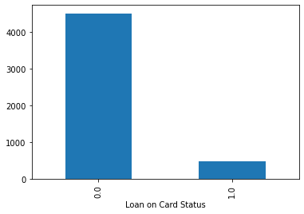

```python
bankData['LoanOnCard'].value_counts().plot(kind='bar')
plt.xlabel('Loan on Card Status');
```

Very Few people have loan on their cards.

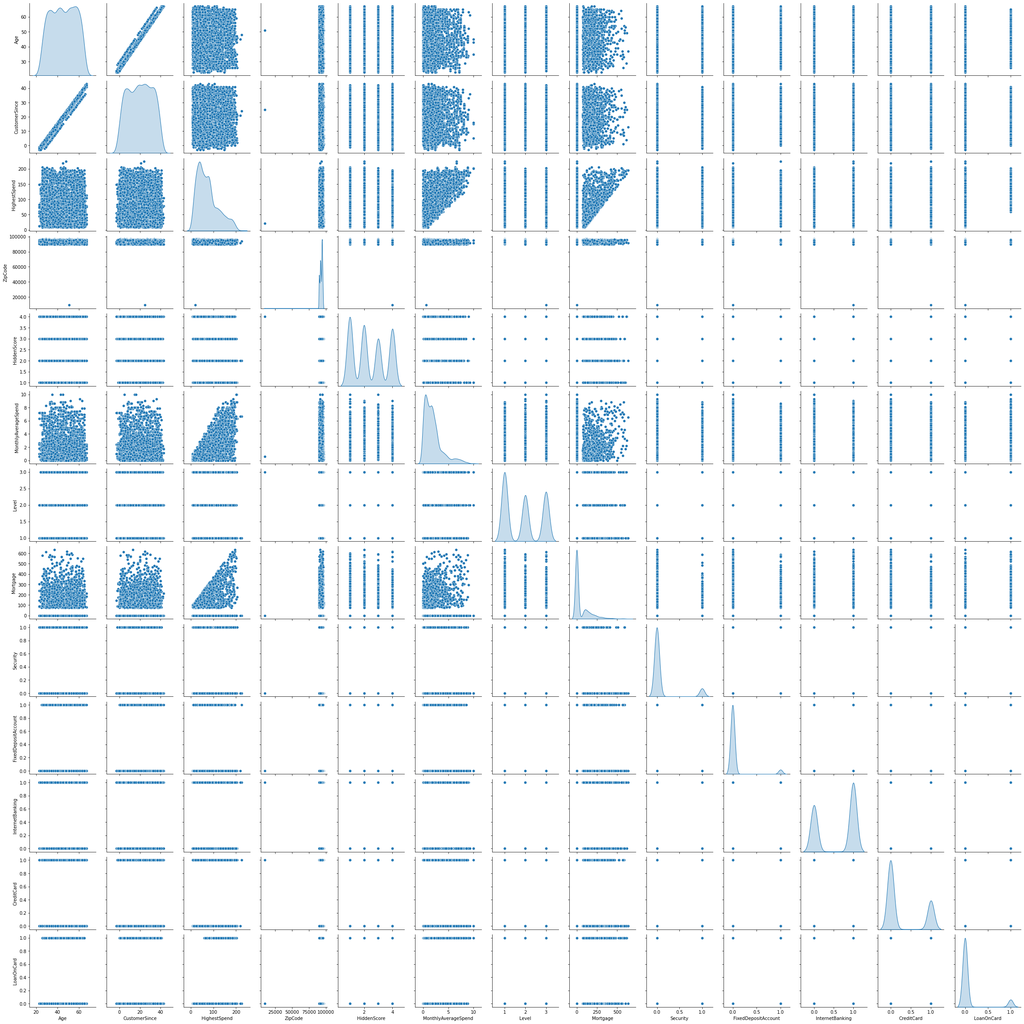

```python
sns.pairplot(data=bankData, diag_kind='kde');
```

```python
bankData.corr()
```

|  | Age | CustomerSince | HighestSpend | ZipCode | HiddenScore | MonthlyAverageSpend | Level | Mortgage | Security | FixedDepositAccount | InternetBanking | CreditCard | LoanOnCard |
| --- | --- | --- | --- | --- | --- | --- | --- | --- | --- | --- | --- | --- | --- |
| Age | 1.000000 | 0.994208 | -0.054951 | -0.029939 | -0.045289 | -0.051896 | 0.042750 | -0.013272 | 0.000323 | 0.007744 | 0.011227 | 0.007344 | -0.008147 |
| CustomerSince | 0.994208 | 1.000000 | -0.046092 | -0.029415 | -0.051456 | -0.049918 | 0.014545 | -0.011380 | -0.000469 | 0.010085 | 0.011355 | 0.008779 | -0.007801 |
| HighestSpend | -0.054951 | -0.046092 | 1.000000 | -0.016447 | -0.158357 | 0.646109 | -0.188909 | 0.207236 | -0.002284 | 0.169535 | 0.014202 | -0.002780 | 0.502626 |
| ZipCode | -0.029939 | -0.029415 | -0.016447 | 1.000000 | 0.012250 | -0.004339 | -0.017274 | 0.007214 | 0.006312 | 0.020007 | 0.017186 | 0.007302 | 0.000120 |
| HiddenScore | -0.045289 | -0.051456 | -0.158357 | 0.012250 | 1.000000 | -0.109180 | 0.065762 | -0.021396 | 0.019061 | 0.014327 | 0.010900 | 0.010784 | 0.061761 |
| MonthlyAverageSpend | -0.051896 | -0.049918 | 0.646109 | -0.004339 | -0.109180 | 1.000000 | -0.137020 | 0.110275 | 0.015105 | 0.136410 | -0.003475 | -0.006577 | 0.366912 |
| Level | 0.042750 | 0.014545 | -0.188909 | -0.017274 | 0.065762 | -0.137020 | 1.000000 | -0.032863 | -0.009443 | 0.013982 | -0.014556 | -0.011766 | 0.137010 |
| Mortgage | -0.013272 | -0.011380 | 0.207236 | 0.007214 | -0.021396 | 0.110275 | -0.032863 | 1.000000 | -0.005002 | 0.089167 | -0.007044 | -0.007600 | 0.141947 |
| Security | 0.000323 | -0.000469 | -0.002284 | 0.006312 | 0.019061 | 0.015105 | -0.009443 | -0.005002 | 1.000000 | 0.317673 | 0.014007 | -0.014518 | 0.021982 |
| FixedDepositAccount | 0.007744 | 0.010085 | 0.169535 | 0.020007 | 0.014327 | 0.136410 | 0.013982 | 0.089167 | 0.317673 | 1.000000 | 0.176082 | 0.278924 | 0.316131 |
| InternetBanking | 0.011227 | 0.011355 | 0.014202 | 0.017186 | 0.010900 | -0.003475 | -0.014556 | -0.007044 | 0.014007 | 0.176082 | 1.000000 | 0.004960 | 0.006034 |
| CreditCard | 0.007344 | 0.008779 | -0.002780 | 0.007302 | 0.010784 | -0.006577 | -0.011766 | -0.007600 | -0.014518 | 0.278924 | 0.004960 | 1.000000 | 0.002536 |
| LoanOnCard | -0.008147 | -0.007801 | 0.502626 | 0.000120 | 0.061761 | 0.366912 | 0.137010 | 0.141947 | 0.021982 | 0.316131 | 0.006034 | 0.002536 | 1.000000 |

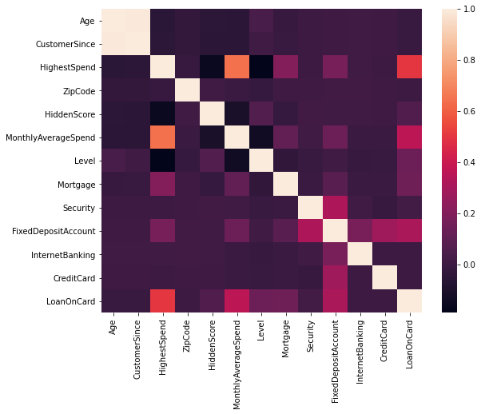

```python
plt.figure(figsize=(9,7))
sns.heatmap(data = bankData.corr())
```

- We can deduce with the pairplot and correlation heatmap that the data is not very correlated to each other
- We can drop either of Age or CustomerSince columns, as they both are highly correlated and provides equal value to the data. Lets drop CustomerSince column

```python
bankData = bankData.drop(['CustomerSince'], axis=1)
```

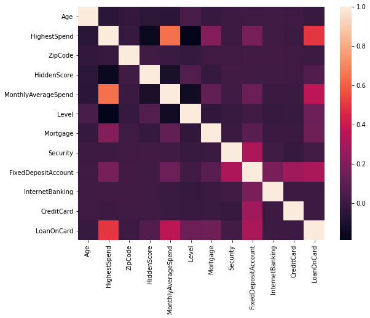

```python
plt.figure(figsize=(9,7))
sns.heatmap(data = bankData.corr());
```

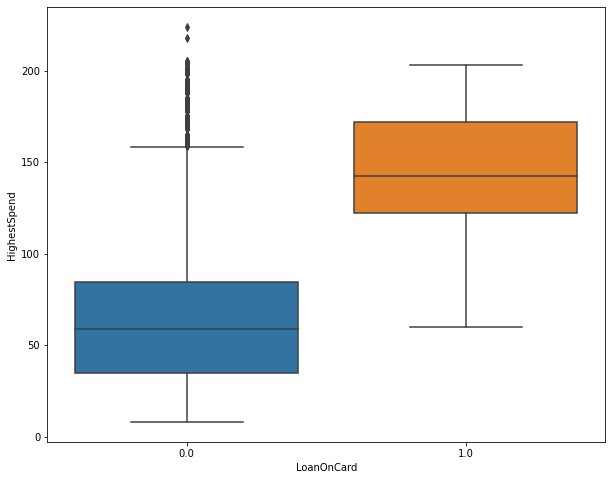

```python
plt.figure(figsize=(10,8))
ax = sns.boxplot(y="HighestSpend", x="LoanOnCard", data=bankData)
```

##### We can also see that their is high number of outliers for the cutomers not having loan on their card. Thpse are the customers having high salary but havent takent any loan. These type of cutomers can be targeted for loan offers.

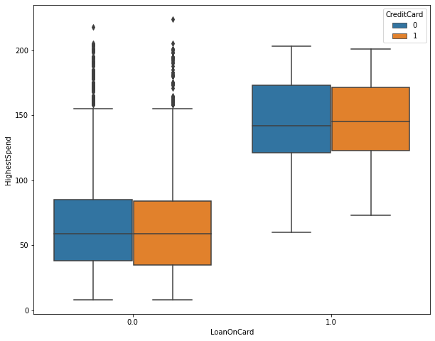

```python
plt.figure(figsize=(10,8))
ax = sns.boxplot(y="HighestSpend", x="LoanOnCard", hue='CreditCard',data=bankData)
```

#### - We can specially target the customer who are having high expenditure and also carry credit cards.

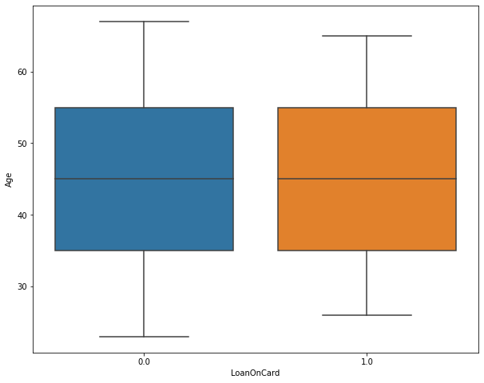

```python
plt.figure(figsize=(10,8))
ax = sns.boxplot(y="Age", x="LoanOnCard",data=bankData)
```

#### Age is cerntainly not a factor for a person to have loam or not in this dataset

```python
bankData.groupby(["LoanOnCard"]).mean()
```

| LoanOnCard | Age | HighestSpend | ZipCode | HiddenScore | MonthlyAverageSpend | Level | Mortgage | Security | FixedDepositAccount | InternetBanking | CreditCard |
| --- | --- | --- | --- | --- | --- | --- | --- | --- | --- | --- | --- |
| 0.0 | 45.383111 | 66.290444 | 93152.337111 | 2.372444 | 1.729849 | 1.843333 | 51.869111 | 0.102222 | 0.036000 | 0.596222 | 0.294000 |
| 1.0 | 45.066667 | 144.745833 | 93153.202083 | 2.612500 | 3.905354 | 2.233333 | 100.845833 | 0.125000 | 0.291667 | 0.606250 | 0.297917 |

### 4. Data pre-processing:

• Segregate predictors vs target attributes  
• Check for target balancing and fix it if found imbalanced.  
• Perform train-test split.

```python
bankX = bankData.drop(['LoanOnCard'], axis=1)
banky= bankData['LoanOnCard']

bankX_train, bankX_test, banky_train, banky_test = train_test_split(bankX, banky, test_size=0.3, random_state=1)
```

```python
bankData.shape
```

```
(4980, 12)
```

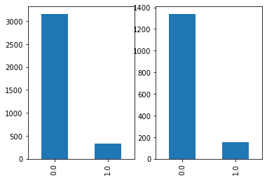

```python
plt.subplot(1,2,1)
banky_train.value_counts().plot(kind = 'bar')

plt.subplot(1,2,2)
banky_test.value_counts().plot(kind = 'bar')
plt.show()
```

```python
bankX_train, banky_train = smote.fit_resample(bankX_train, banky_train)
bankX_test, banky_test = smote.fit_resample(bankX_test,banky_test)
```

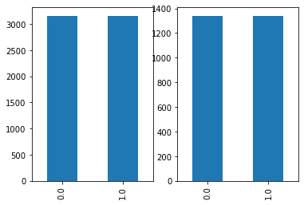

```python
plt.subplot(1,2,1)
banky_train.value_counts().plot(kind = 'bar')

plt.subplot(1,2,2)
banky_test.value_counts().plot(kind = 'bar')
plt.show()
```

##### - Both training and testing data is found to be imbalanced and delt with usint SMOTE technique

##### - Data is splitted into training and testing

### 5. Model training, testing and tuning:

• Design and train a Logistic regression and Naive Bayes classifiers.  
• Display the classification accuracies for train and test data.  
• Display and explain the classification report in detail.  
• Apply all the possible tuning techniques to train the best model for the given data. Select the final best trained model with your comments for selecting this model.

### Training Logistic regression

```python
from sklearn.linear_model import LogisticRegression
```

```python
logReg = LogisticRegression()

logReg.fit(bankX_train, banky_train)

banky_train_Predicted = logReg.predict(bankX_train)
print("Training accuracy: {} ".format(accuracy_score(banky_train,banky_train_Predicted)))

banky_test_predicted = logReg.predict(bankX_test)

print("Testing Accuracy: {}".format(accuracy_score(banky_test,banky_test_predicted)))
```

```
Training accuracy: 0.8806584362139918
Testing Accuracy: 0.866144668158091
```

```python
logReg1 = LogisticRegression(penalty='l1',solver='liblinear',C=0.1,max_iter=1000)

logReg1.fit(bankX_train, banky_train)

banky_train_Predicted = logReg1.predict(bankX_train)
print("Training accuracy: {} ".format(accuracy_score(banky_train,banky_train_Predicted)))

banky_test_predicted = logReg.predict(bankX_test)

print("Testing Accuracy: {}".format(accuracy_score(banky_test,banky_test_predicted)))
```

```
Training accuracy: 0.9009180120291231
Testing Accuracy: 0.866144668158091
```

```python
logReg2 = LogisticRegression(penalty='elasticnet',solver='saga',C=0.1,max_iter=1000, l1_ratio=0.5)

logReg2.fit(bankX_train, banky_train)

banky_train_Predicted = logReg2.predict(bankX_train)
print("Training accuracy: {} ".format(accuracy_score(banky_train,banky_train_Predicted)))

banky_test_predicted = logReg.predict(bankX_test)

print("Testing Accuracy: {}".format(accuracy_score(banky_test,banky_test_predicted)))
```

```
Training accuracy: 0.8746438746438746
Testing Accuracy: 0.866144668158091
```

```python
bank_train_CM = metrics.confusion_matrix(banky_train, banky_train_Predicted)

bank_df_cm = pd.DataFrame(bank_train_CM,
                    index = [i for i in ['0','1']],
                    columns= [i for i in ['P-Loan-1 ','P-NoLoan-0']])

bank_df_cm
```

[output not shown]

```python
bank_test_CM = metrics.confusion_matrix(banky_test, banky_test_predicted)

bank_testdf_cm = pd.DataFrame(bank_test_CM,
                    index = [i for i in ['0','1']],
                    columns= [i for i in ['P-Loan-1 ','P-NoLoan-0']])

bank_testdf_cm
```

|  | P-Loan-1 | P-NoLoan-0 |
| --- | --- | --- |
| 0 | 1128 | 213 |
| 1 | 146 | 1195 |

```python
from sklearn.metrics import classification_report

cr = classification_report(banky_test, banky_test_predicted)
print(cr)
```

```
              precision    recall  f1-score   support

         0.0       0.89      0.84      0.86      1341
         1.0       0.85      0.89      0.87      1341

    accuracy                           0.87      2682
   macro avg       0.87      0.87      0.87      2682
weighted avg       0.87      0.87      0.87      2682
```

From the above classification report we can see that all precision, recall and accuracy is around 86%.

### Building Naive-Bayes Model

```python
BNB.fit(bankX_train, banky_train)

banky_train_Predicted = BNB.predict(bankX_train)
print("Training accuracy: {} ".format(accuracy_score(banky_train,banky_train_Predicted)))

banky_test_predicted = BNB.predict(bankX_test)

print("Testing Accuracy: {}".format(accuracy_score(banky_test,banky_test_predicted)))
```

```
Training accuracy: 0.6706236150680596
Testing Accuracy: 0.6972408650260999
```

```python
naivebayes = GaussianNB()

naivebayes.fit(bankX_train, banky_train)

banky_train_Predicted = naivebayes.predict(bankX_train)
print("Training accuracy: {} ".format(accuracy_score(banky_train,banky_train_Predicted)))

banky_test_predicted = naivebayes.predict(bankX_test)

print("Testing Accuracy: {}".format(accuracy_score(banky_test,banky_test_predicted)))
```

```
Training accuracy: 0.899335232668566
Testing Accuracy: 0.8780760626398211
```

```python
nb_CM = metrics.confusion_matrix(banky_test, banky_test_predicted)

nbdf_cm = pd.DataFrame(bank_test_CM,
                    index = [i for i in ['0','1']],
                    columns= [i for i in ['P-Loan-1 ','P-NoLoan-0']])

nbdf_cm
```

|  | P-Loan-1 | P-NoLoan-0 |
| --- | --- | --- |
| 0 | 1128 | 213 |
| 1 | 146 | 1195 |

```python
cr = classification_report(banky_test, banky_test_predicted)
print(cr)
```

```
              precision    recall  f1-score   support

         0.0       0.88      0.87      0.88      1341
         1.0       0.87      0.89      0.88      1341

    accuracy                           0.88      2682
   macro avg       0.88      0.88      0.88      2682
weighted avg       0.88      0.88      0.88      2682
```

##### From the above classification report we can see that all precision, recall and accuracy is around 88%. And I chose naive bayes gaussian model to be the best in this case, as it gives the maximum accuracy score.

### 6. Conclusion and improvisation:

• Write your conclusion on the results.  
• Detailed suggestions or improvements or on quality, quantity, variety, velocity, veracity etc. on the data points collected by the  
bank to perform a better data analysis in future.

##### - As per our bivariate plot, we can say that HigestSpend can be our most significant independent variable. As it says a lot about whether a cstomer can afford to pay loan amount on time.

##### - Accuracy can be improved further using using alternated model or adding more variables

##### - Most of the customers having loan are having HigestSpend between 120 - 175 (approx)

##### - There are high number of outliers present for the cutomers not having loan on their card

##### - Data is highly imbalanced

### Comments on data

##### - There are columns like Zipcode, Internet Banking, Age which are not useful for the analysis that we are carrying here.

##### - Data is good as the categorical data was already in 0 and 1 form.

##### - only 20 rows had missing data, which is quite okay.